# R Notebook for the Strabismus thesis

Pascal Jerney[^1], Prof. Dr. Daniel S. Mojon[^2]

Created 14th July 2019

# Problem

Squint surgery in adults is commonly considered as aesthetic surgery and therefore not covered by statutory health insurance. We aim to show that squint in adults has a significant impact on social life and business and corrective surgery should be included in standard insurance benefits.

To show the negative impact of strabismus we collect Likert-type data using a validated questionnaire distributed over the Internet.

# Plan

Obsolete.

# Data

## Experiment

### Stimulus persons

Stimulus persons were created by merging two faces together, the base (normal) pictures are used by courtesy of Prof. Martin Gründl from [Beautycheck](http://www.beautycheck.de). The faces were then modified having exophoria (**why?**), acne, eyebrow piercing or temporal tattoo with [Adobe Photoshop](https://www.adobe.com/products/photoshop.html).

Stimulus persons

Face

Normal (0)

Strabismus (1)

Acne (2)

Piercing (3)

Tattoo (4)

A

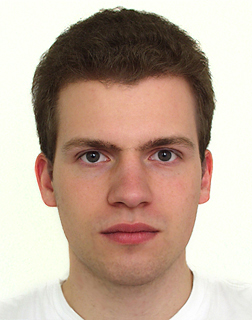

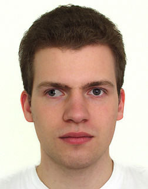

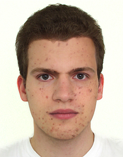

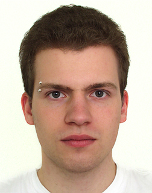

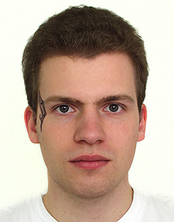

B

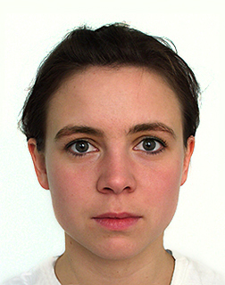

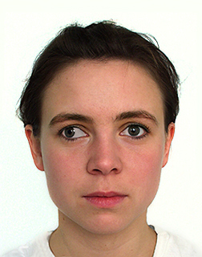

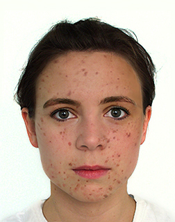

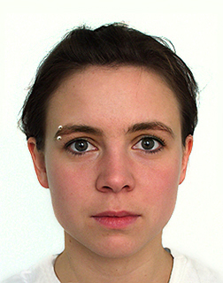

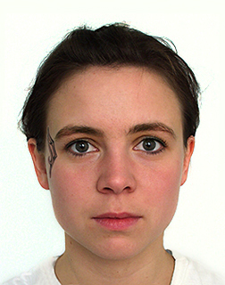

C

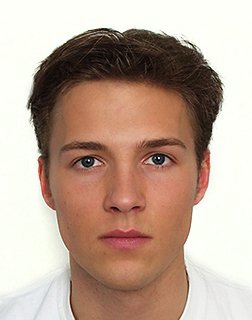

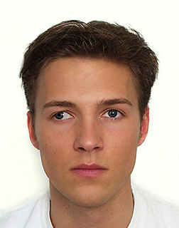

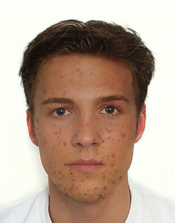

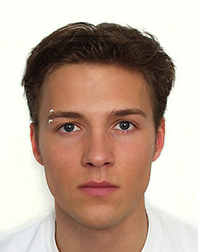

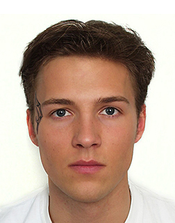

D

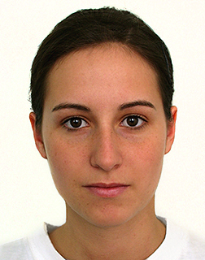

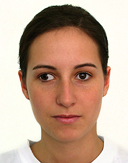

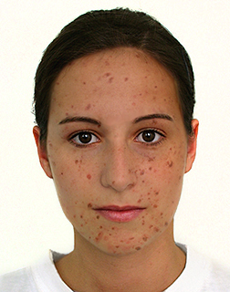

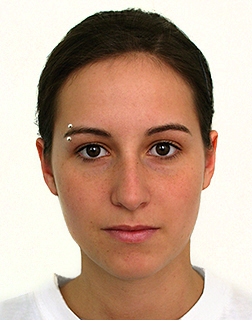

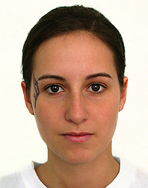

### Survey structure

Participants were allocated first to either getting an appendectomy or having a medical checkup (variable `situation`) with a probability of 0.5 each. They were subsequently allocated to one of five treatment groups (variable `trt_group`) being 0 the control group with a probability of 0.2 each. The participants were shown four pictures according to the following order:

Picture order by treatment group

| Treatment group |  |  |  |  |
| --- | --- | --- | --- | --- |
| 0 (Control) | A0 | B0 | C0 | D0 |
| 1 | A1 | B2 | C3 | D4 |
| 2 | A2 | B3 | C4 | D1 |
| 3 | A3 | B4 | C1 | D2 |
| 4 | A4 | B1 | C2 | D3 |

For every picture, participants were asked, how likely they would have the operation or checkup performed by this physician on a Likert scale from 0 (not at all) to 10 (definitely) (variable `answer`). They also had to rate the shown physician regarding their perceived reliability, honesty, attractiveness, intelligence, compentence and kindness, again on a Likert scale from 0 (not at all) to 10 (maximal). Lastly, they were asked to rate the importance of the aforementioned characteristics in a surgeon or internist respectively, again on the same Likert scale.

### Data collection

Data was collected using an Internet-based [survey form](http://survey.jerney.ch), which has been programmed with the [CodeIgniter](https://www.codeigniter.com) framework. Demographic data involved gender, age and nationality. To be able to recognise double respondents, the IP address was registered, as well as the date and start/end time. Lastly, the admission mode (email, another website) was collected.

## Results

### Data cleaning

Data was exported from website database as comma-separated text (CSV) into a participant and an answers file. Both files were imported into [RStudio](https://www.rstudio.com), a statistical computing environment based on [R](https://www.r-project.org/), with the help of the [tidyverse](https://www.tidyverse.org/) packages.

Exclusion criteria for participants were missing values, age lower than 16 or greater than 99 and an answer duration lower than 93 seconds or greater than 467 seconds (**why?**).

Start and end date of collected data

| Earliest | Latest |
| --- | --- |
| 2011-02-28 | 2019-07-29 |

### Demographics

Participant baseline characteristics

|  | Control | Group_1 | Group_2 | Group_3 | Group_4 | p | test |
| --- | --- | --- | --- | --- | --- | --- | --- |
| n | 1910 | 1896 | 1808 | 1753 | 1772 |  |  |
| age (median [IQR]) | 23.00 [19.00, 30.00] | 23.00 [19.00, 30.00] | 23.00 [19.00, 31.00] | 23.00 [19.00, 31.00] | 23.00 [19.00, 31.00] | 0.611 | nonnorm |
| gender = Female (%) | 1374 (71.9) | 1380 (72.8) | 1293 (71.5) | 1248 (71.2) | 1280 (72.2) | 0.845 |  |
| country (%) |  |  |  |  |  | 0.642 |  |
| CH | 152 (8.0) | 148 (7.8) | 164 (9.1) | 138 (7.9) | 129 (7.3) |  |  |
| DE | 1114 (58.3) | 1089 (57.4) | 1058 (58.5) | 1035 (59.0) | 1017 (57.4) |  |  |
| IT | 9 (0.5) | 16 (0.8) | 17 (0.9) | 11 (0.6) | 16 (0.9) |  |  |
| AT | 103 (5.4) | 117 (6.2) | 105 (5.8) | 114 (6.5) | 104 (5.9) |  |  |
| US | 225 (11.8) | 193 (10.2) | 172 (9.5) | 172 (9.8) | 203 (11.5) |  |  |
| NL | 11 (0.6) | 13 (0.7) | 10 (0.6) | 6 (0.3) | 8 (0.5) |  |  |
| GB | 34 (1.8) | 51 (2.7) | 51 (2.8) | 44 (2.5) | 42 (2.4) |  |  |
| TR | 22 (1.2) | 14 (0.7) | 19 (1.1) | 11 (0.6) | 10 (0.6) |  |  |
| AU | 13 (0.7) | 14 (0.7) | 17 (0.9) | 12 (0.7) | 15 (0.8) |  |  |
| FR | 12 (0.6) | 16 (0.8) | 8 (0.4) | 10 (0.6) | 10 (0.6) |  |  |
| CA | 26 (1.4) | 35 (1.8) | 28 (1.5) | 32 (1.8) | 30 (1.7) |  |  |
| Other | 189 (9.9) | 190 (10.0) | 159 (8.8) | 168 (9.6) | 188 (10.6) |  |  |
| situation = Surgeon (%) | 953 (49.9) | 976 (51.5) | 911 (50.4) | 900 (51.3) | 844 (47.6) | 0.140 |  |
| year (%) |  |  |  |  |  | 0.117 |  |
| 2011 | 640 (33.5) | 674 (35.5) | 642 (35.5) | 613 (35.0) | 624 (35.2) |  |  |
| 2012 | 473 (24.8) | 468 (24.7) | 450 (24.9) | 405 (23.1) | 408 (23.0) |  |  |
| 2013 | 345 (18.1) | 321 (16.9) | 314 (17.4) | 310 (17.7) | 319 (18.0) |  |  |
| 2014 | 227 (11.9) | 219 (11.6) | 210 (11.6) | 259 (14.8) | 239 (13.5) |  |  |
| 2015 | 193 (10.1) | 181 (9.5) | 160 (8.8) | 134 (7.6) | 148 (8.4) |  |  |
| 2016 | 26 (1.4) | 27 (1.4) | 29 (1.6) | 22 (1.3) | 31 (1.7) |  |  |
| 2019 | 6 (0.3) | 6 (0.3) | 3 (0.2) | 10 (0.6) | 3 (0.2) |  |  |
| duration (median [IQR]) | 205.00 [168.00, 255.00] | 207.00 [171.00, 255.00] | 211.00 [172.75, 262.00] | 208.00 [172.00, 258.00] | 210.00 [173.00, 260.00] | 0.075 | nonnorm |

# Conclusion

[^1]: University of Berne, Switzerland
[^2]: University of Berne, Switzerland